# Pilot study: summary and analysis

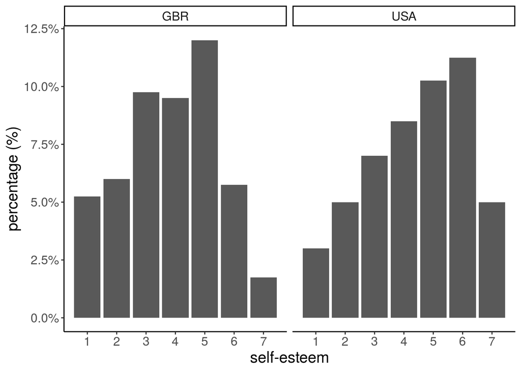

```r
df_selfesteem <-

    df %>%
    summary_stats("self_esteem")

df_selfesteem_plot <-

    df %>%
    ggplot(aes(x = self_esteem)) +
    geom_bar(aes(y = (..count..)/sum(..count..))) + #    geom_histogram(stat = "count") +
    labs(x = "self-esteem") +
    ## scale_x_binned(n.breaks = 7) +
    scale_x_continuous(breaks = unique(df$self_esteem)) + #, lim = c(1,7)) +
    scale_y_continuous("percentage (%)", labels = scales::percent) +
    facet_wrap(. ~ country) +
    theme_classic() +
    theme(text = element_text(size = 15))

df_selfesteem_plot
```

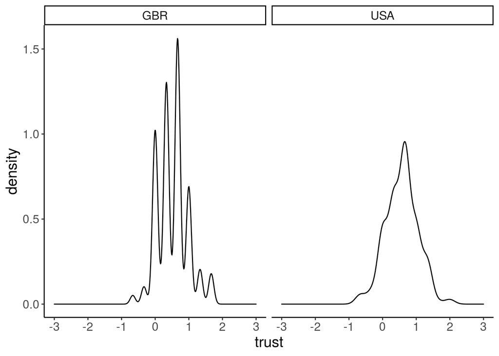

```r
df_trust <-

    df %>%
    summary_stats("trust_in_out")


df_trust_plot_country <-

    df %>%
    ggplot(aes(trust_in_out)) +
    geom_density() +
    facet_wrap(. ~ country) +
    theme_classic() +
    labs(x = "trust") +
    scale_x_continuous(limits = c(-3, 3), breaks = seq(-3, 3, 1)) +
    theme(text = element_text(size = 15))


df_trust_plot_country
```

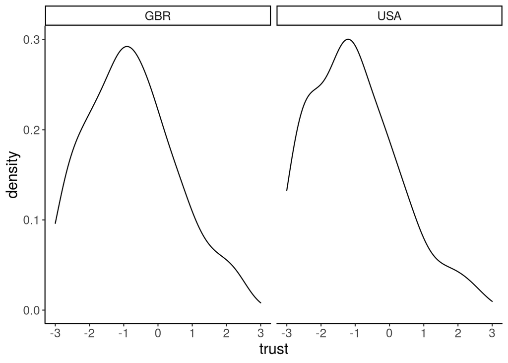

```r
df_permeability <-

    df %>%
    summary_stats("permeability")


df_permeability_plot_country <-

    df %>%
    ggplot(aes(permeability)) +
    geom_density() +
    facet_wrap(. ~ country) +
    theme_classic() +
    labs(x = "trust") +
    scale_x_continuous(limits = c(-3, 3), breaks = seq(-3, 3, 1)) +
    theme(text = element_text(size = 15))

df_permeability_plot_country
```

Self-esteem (single-item) had a mean of 4.13 (SD = 1.69, range 1–7). The composite trust score had a mean of 0.55 (SD = 0.46, range -0.67–2). The composite permeability score had a mean of -1.71 (SD = 2.12, range -8–4.83).

## Research question 1

We then use outcome minimal bias (min_bias), which includes all three (standardised) measures of bias with the minimal groups. Measure can then be include as a random effect.

We can run the model either with measure combined or as dummy; I find it easier to extract country-level random effects if we use dummy.

```r
## model with country
model_country_all <-

    lmerTest::lmer(min_bias ~ measure +
                       (1 | id)  +
                       (measure | country/lab),
                   data = df_rq1
                   ## , contrasts = list(measure = "contr.sum")
                   )

## summary
summary(model_country_all)
```

```
## Linear mixed model fit by REML. t-tests use Satterthwaite's method [
## lmerModLmerTest]
## Formula: min_bias ~ measure + (1 | id) + (measure | country/lab)
##    Data: df_rq1
##
## REML criterion at convergence: 3307
##
## Scaled residuals:
##    Min     1Q Median     3Q    Max
## -6.494 -0.426 -0.189  0.244  4.831
##
## Random effects:
##  Groups      Name            Variance  Std.Dev. Corr
##  id          (Intercept)     0.3157436 0.56191
##  lab:country (Intercept)     0.0010842 0.03293
##              measuredg_first 0.0000743 0.00862  -1.00
##              measuredg_third 0.0022320 0.04724  -1.00  1.00
##  country     (Intercept)     0.0009710 0.03116
##              measuredg_first 0.0000663 0.00814  -1.00
##              measuredg_third 0.0019934 0.04465  -1.00  1.00
##  Residual                    0.6836514 0.82683
## Number of obs: 1200, groups:  id, 400; lab:country, 2; country, 2
##
## Fixed effects:
##                  Estimate Std. Error        df t value Pr(>|t|)
## (Intercept)     -4.67e-16   5.94e-02  1.62e+00       0        1
## measuredg_first  7.81e-17   5.91e-02  2.40e+01       0        1
## measuredg_third  3.62e-16   7.44e-02  1.21e+00       0        1
##
## Correlation of Fixed Effects:
##             (Intr) msrdg_f
## mesrdg_frst -0.564
## mesrdg_thrd -0.721  0.477
## convergence code: 0
## boundary (singular) fit: see ?isSingular
```

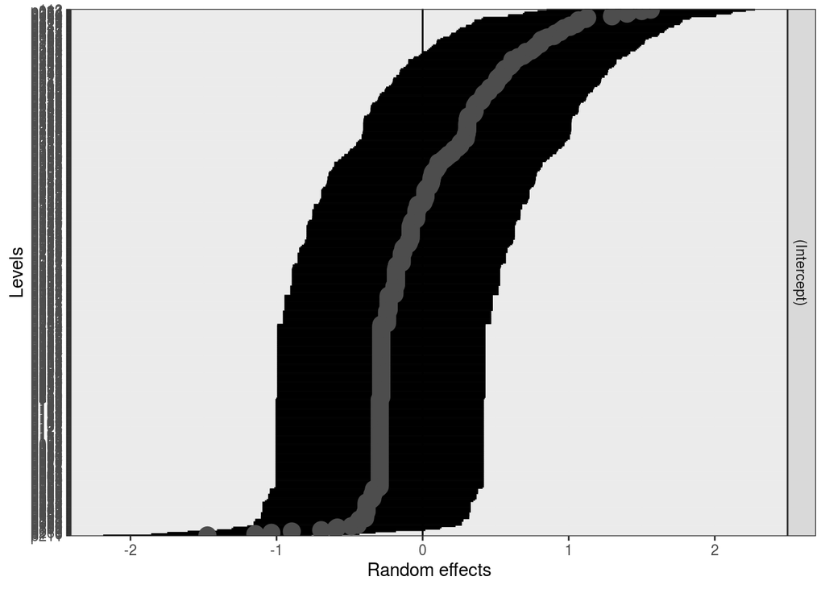

```
##
## $`lab:country`
```

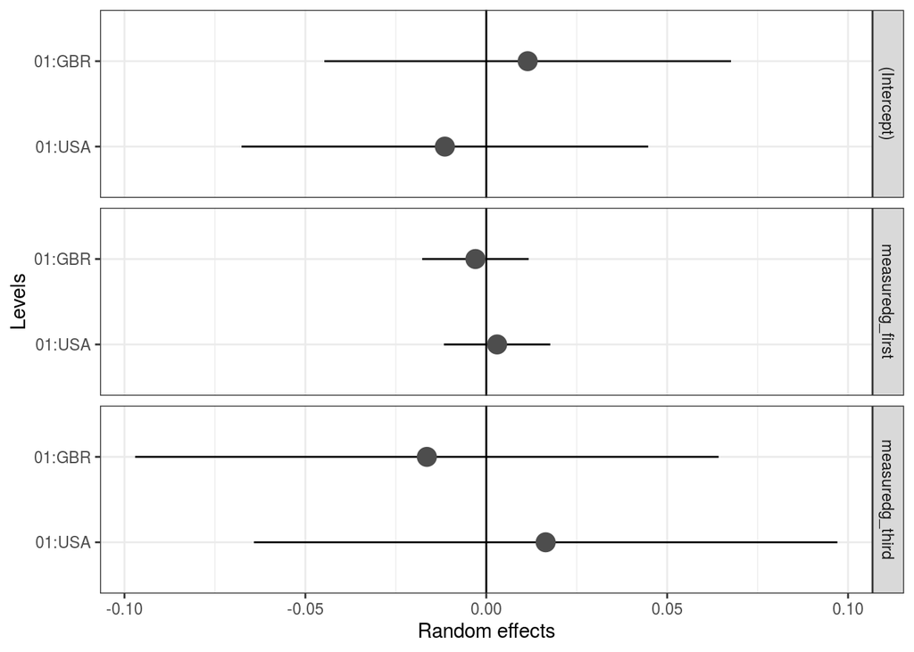

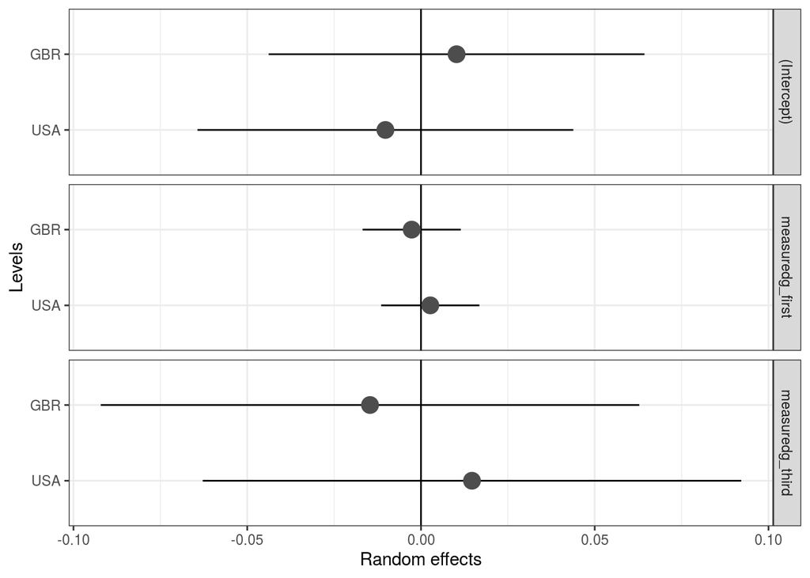

```r
## dotplot
gg_caterpillar(ranef(model_country_all, condVar = TRUE), QQ = FALSE,
              likeDotplot = FALSE)
```

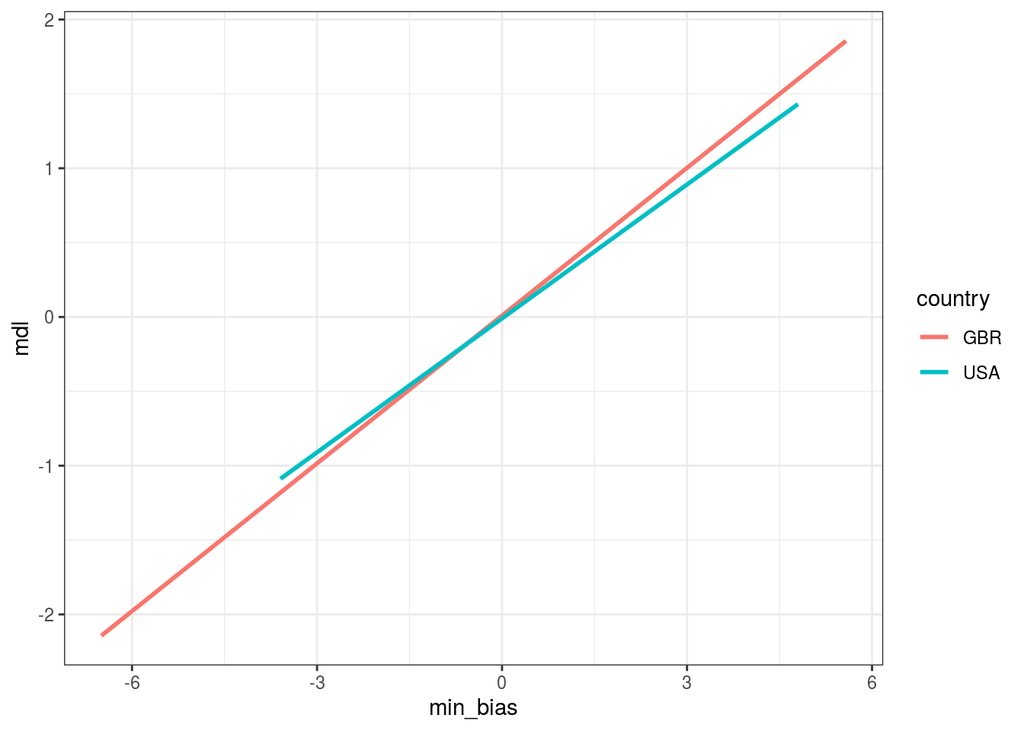

```r
## predict the scores based on the model
df_rq1 %>%
  mutate(mdl = predict(model_country_all)) %>%
  ggplot(aes(min_bias, y = mdl, colour = country, group = country)) +
  geom_smooth(se = F, method = lm) +
  theme_bw()
```

```r
## country
model_country_dummy <-

    lmerTest::lmer(min_bias ~ att_dummy + dg_first_dummy +
                       (1 | id)  +
                       (att_dummy + dg_first_dummy + dg_third_dummy | country/lab),
                   data = df_rq1)

## summary
summary(model_country_dummy)
```

```
## Linear mixed model fit by REML. t-tests use Satterthwaite's method [
## lmerModLmerTest]
## Formula: min_bias ~ att_dummy + dg_first_dummy + (1 | id) + (att_dummy +
##     dg_first_dummy + dg_third_dummy | country/lab)
##    Data: df_rq1
##
## REML criterion at convergence: 3307
##
## Scaled residuals:
##    Min     1Q Median     3Q    Max
## -6.494 -0.426 -0.189  0.244  4.831
##
## Random effects:
##  Groups      Name           Variance  Std.Dev. Corr
##  id          (Intercept)    0.3157602 0.56193
##  lab:country (Intercept)    0.0000206 0.00454
##              att_dummy      0.0022528 0.04746  -1.00
##              dg_first_dummy 0.0013101 0.03620  -1.00  1.00
##              dg_third_dummy 0.0001967 0.01403   1.00 -1.00 -1.00
##  country     (Intercept)    0.0000000 0.00000
##              att_dummy      0.0002140 0.01463    NaN
##              dg_first_dummy 0.0001163 0.01079    NaN  1.00
##              dg_third_dummy 0.0000401 0.00633    NaN -1.00 -1.00
##  Residual                   0.6836433 0.82683
## Number of obs: 1200, groups:  id, 400; lab:country, 2; country, 2
##
## Fixed effects:
##                 Estimate Std. Error        df t value Pr(>|t|)
## (Intercept)    -1.52e-16   5.19e-02  6.85e+00       0        1
## att_dummy      -4.33e-17   7.44e-02  1.22e+00       0        1
## dg_first_dummy -9.16e-17   6.95e-02  1.62e+00       0        1
##
## Correlation of Fixed Effects:
##             (Intr) att_dm
## att_dummy   -0.608
## dg_frst_dmm -0.619  0.665
## convergence code: 0
## boundary (singular) fit: see ?isSingular
```

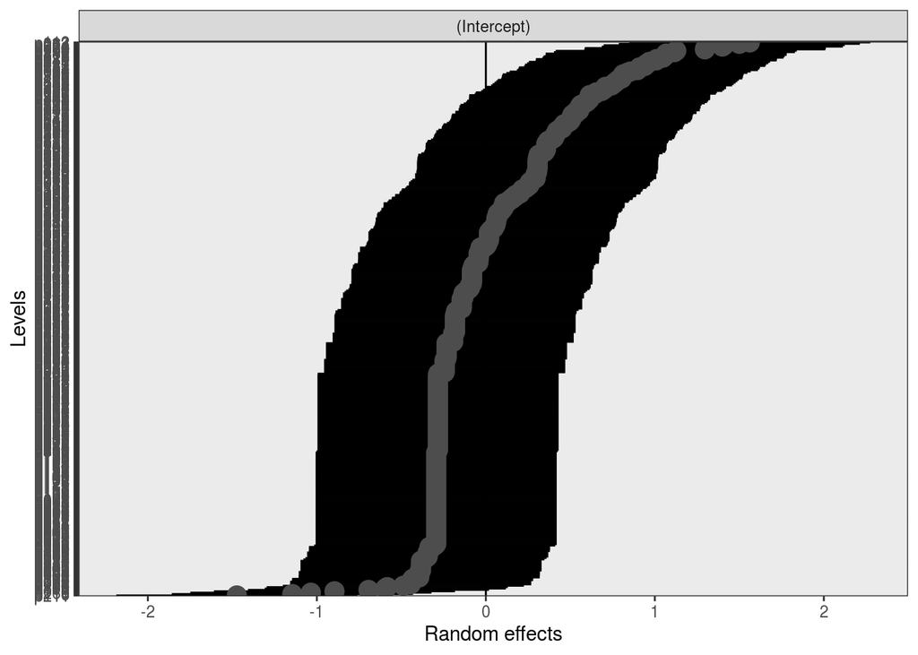

```
##
## $`lab:country`
```

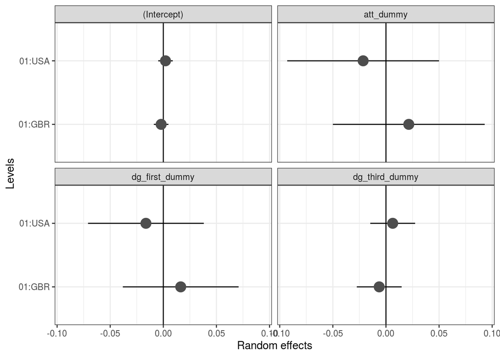

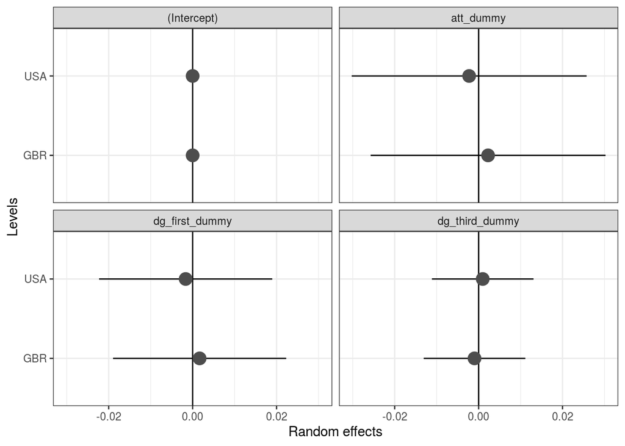

```r
## icc
## country variance / (residual + country variance)

## dotplot
gg_caterpillar(ranef(model_country_dummy, condVar = TRUE), QQ = FALSE,
              likeDotplot = TRUE)
```

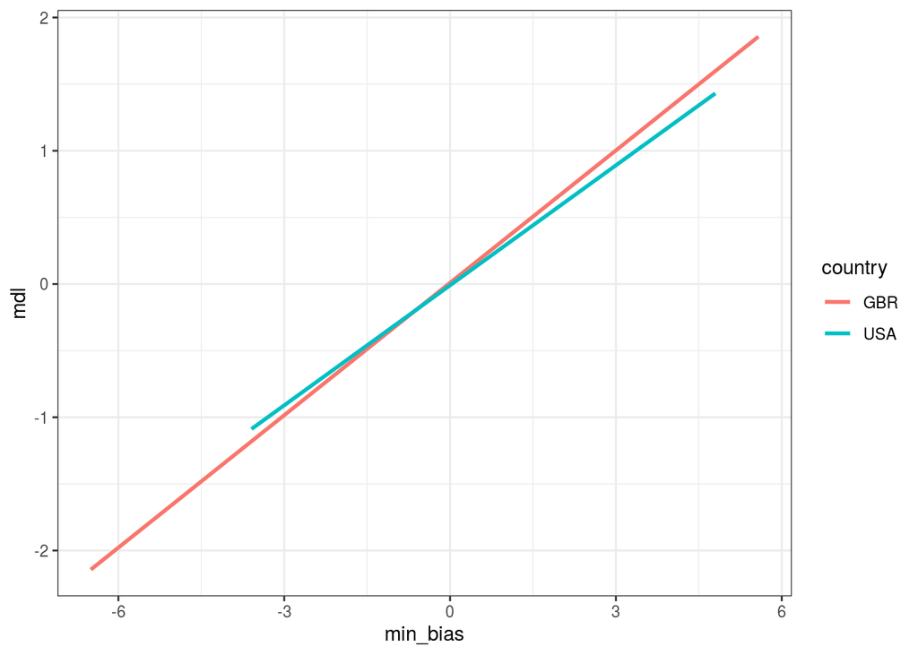

```r
## graph with predicted country level min bias

## predict the scores based on the model
df_rq1 %>%
  mutate(mdl = predict(model_country_dummy)) %>%
  ggplot(aes(min_bias, y = mdl, colour = country, group = country)) +
  geom_smooth(se = FALSE, method = lm) +
  theme_bw()
```

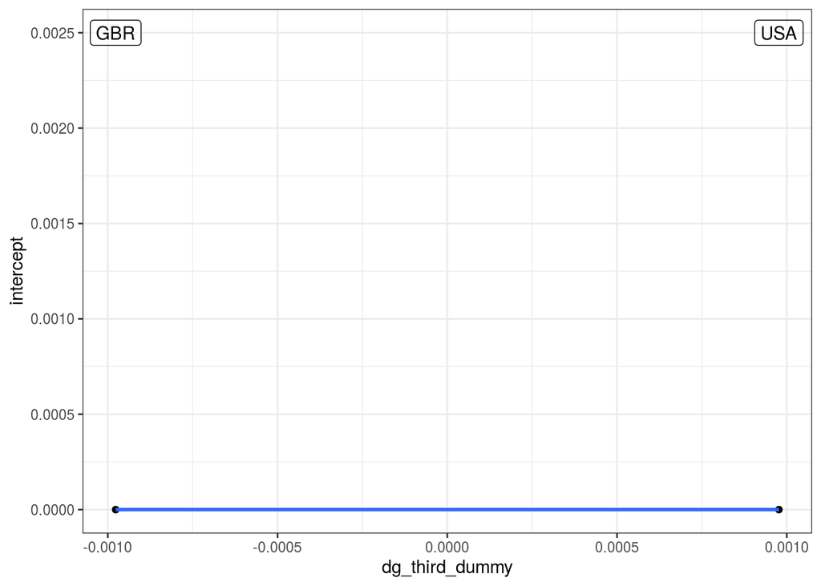

```r
## graph of random effects with line of best fit

## save coefficients
coefs_model <- coef(model_country_dummy)

## print random effects and best line
## shown is just dg_third_dummy
coefs_model$country %>%
  mutate(country = rownames(coefs_model$country),
         intercept = `(Intercept)`) %>%
  ggplot(aes(x = dg_third_dummy, y = intercept, label = country)) +
  geom_point() +
  geom_smooth(se = F, method = lm) +
  geom_label(nudge_y = 0.0025, alpha = 0.5) +
  theme_bw()
```

## Research question 2

For the individual level analysis of research question 2, we have three main moderators of interest: permeability, (in-group and out-group) trust, and self-esteem. We compare various models:

```r
## minimal model
model_rq2_min <-

    lmerTest::lmer(
        min_bias ~ measure +
          (1 | id)  +
          (self_esteem + trust + permeability | country/lab),
        data = df_rq2)

## model with esteem
model_rq2_esteem <-

    lmerTest::lmer(
        min_bias ~ measure * self_esteem +
          (1 | id)  +
          (self_esteem + trust + permeability | country/lab),
        data = df_rq2)

## model with trust
model_rq2_trust <-

    lmerTest::lmer(
        min_bias ~ measure * trust +
          (1 | id)  +
          (self_esteem + trust + permeability | country/lab),
        data = df_rq2)

## model with esteem and trust
model_rq2_esteem_trust <-

    lmerTest::lmer(
        min_bias ~ measure * (self_esteem + trust) +
          (1 | id)  +
          (self_esteem + trust + permeability | country/lab),
        data = df_rq2)

## model permeability
model_rq2_permeability <-

    lmerTest::lmer(
        min_bias ~ measure * permeability +
          (1 | id)  +
          (self_esteem + trust + permeability | country/lab),
        data = df_rq2)

## maximal model
model_rq2_max <-

    lmerTest::lmer(
        min_bias ~ measure * (self_esteem + trust + permeability) +
          (1 | id)  +
          (self_esteem + trust + permeability | country/lab),
        data = df_rq2)

## compare models
anova(model_rq2_min,
      model_rq2_esteem,
      model_rq2_trust,
      model_rq2_esteem_trust,
      model_rq2_permeability,
      model_rq2_max)
```

|  | npar | AIC | BIC | logLik | deviance | Chisq | Df | Pr(>Chisq) |
| --- | --- | --- | --- | --- | --- | --- | --- | --- |
| model_rq2_min | 25 | 3338 | 3465 | -1644 | 3288 | NA | NA | NA |
| model_rq2_esteem | 28 | 3336 | 3478 | -1640 | 3280 | 8.41 | 3 | 0.0383 |
| model_rq2_trust | 28 | 3335 | 3478 | -1640 | 3279 | 0.35 | 0 | 0.0000 |
| model_rq2_permeability | 28 | 3339 | 3482 | -1641 | 3283 | 0.00 | 0 | 1.0000 |
| model_rq2_esteem_trust | 31 | 3332 | 3490 | -1635 | 3270 | 12.58 | 3 | 0.0056 |
| model_rq2_max | 34 | 3334 | 3507 | -1633 | 3266 | 4.73 | 3 | 0.1925 |

```r
## excplicitly AIC comparison, although above considers it with ML
AIC(model_rq2_min,
    model_rq2_esteem,
    model_rq2_trust,
    model_rq2_esteem_trust,
    model_rq2_permeability,
    model_rq2_max)
```

|  | df | AIC |
| --- | --- | --- |
| model_rq2_min | 25 | 3351 |
| model_rq2_esteem | 28 | 3364 |
| model_rq2_trust | 28 | 3356 |
| model_rq2_esteem_trust | 31 | 3369 |
| model_rq2_permeability | 28 | 3368 |
| model_rq2_max | 34 | 3386 |

## Research question 3

For research question 3, we assess whether real-world bias (towards the nation and/or family) is predicted by minimal group bias.

```r
## longish dataframe with relevant vars
## NB for only one measure
df_rq3_att <-

    df %>%
    select(id, lab, country,
           att_min_bias, att_nat_bias, att_fam_bias,
           dg_min_bias_first, dg_nat_bias_first, dg_fam_bias_first) %>%
    pivot_longer(cols = c(att_nat_bias, att_fam_bias),,
                 names_to = "group_type",
                 values_to = "att_real_bias") %>%
    mutate(group_type = case_when(str_detect(group_type, "nat") ~ "nat",
                                  str_detect(group_type, "fam") ~ "fam"
                                  ))

df_rq3_dg_first <-

    df %>%
    select(id, lab, country,
           ## att_min_bias, att_nat_bias, att_fam_bias,
           dg_min_bias_first, dg_nat_bias_first, dg_fam_bias_first) %>%
    pivot_longer(cols = c(dg_nat_bias_first, dg_fam_bias_first),,
                 names_to = "group_type",
                 values_to = "dg_real_bias_first") %>%
    mutate(group_type = case_when(str_detect(group_type, "nat") ~ "nat",
                                  str_detect(group_type, "fam") ~ "fam"
                                  ))

df_rq3_dg_third <-

    df %>%
    select(id, lab, country,
           ## att_min_bias, att_nat_bias, att_fam_bias,
           dg_min_bias_third, dg_nat_bias_third, dg_fam_bias_third) %>%
    pivot_longer(cols = c(dg_nat_bias_third, dg_fam_bias_third),,
                 names_to = "group_type",
                 values_to = "dg_real_bias_third") %>%
    mutate(group_type = case_when(str_detect(group_type, "nat") ~ "nat",
                                  str_detect(group_type, "fam") ~ "fam"
                                  ))

## peek at dataframe
head(df_rq3_att)
```

| id | lab | country | att_min_bias | dg_min_bias_first | dg_nat_bias_first | dg_fam_bias_first | group_type | att_real_bias |
| --- | --- | --- | --- | --- | --- | --- | --- | --- |
| p001 | 01 | GBR | 2.0 | 0 | 0 | 0 | nat | 0.5 |
| p001 | 01 | GBR | 2.0 | 0 | 0 | 0 | fam | -1.0 |
| p002 | 01 | GBR | 0.5 | 0 | 0 | 0 | nat | -1.2 |
| p002 | 01 | GBR | 0.5 | 0 | 0 | 0 | fam | -0.5 |
| p003 | 01 | GBR | 0.5 | 3 | -3 | 0 | nat | -2.2 |
| p003 | 01 | GBR | 0.5 | 3 | -3 | 0 | fam | 1.0 |

To avoid three-way interactions, we model each measure separately.

### Attitude

We first demonstrate the analysis with the attitude measures.

```r
## real-world
model_real_world <-

    lmerTest::lmer(att_real_bias ~ att_min_bias * group_type +
                       (1 | id)  +
                       (att_min_bias + group_type | country/lab),
                   data = df_rq3_att)

## summary
summary(model_real_world)
```

```
## Linear mixed model fit by REML. t-tests use Satterthwaite's method [
## lmerModLmerTest]
## Formula:
## att_real_bias ~ att_min_bias * group_type + (1 | id) + (att_min_bias +
##     group_type | country/lab)
##    Data: df_rq3_att
##
## REML criterion at convergence: 2627
##
## Scaled residuals:
##    Min     1Q Median     3Q    Max
## -4.245 -0.411  0.019  0.475  2.586
##
## Random effects:
##  Groups      Name          Variance  Std.Dev. Corr
##  id          (Intercept)   0.3839132 0.61961
##  lab:country (Intercept)   0.0013069 0.03615
##              att_min_bias  0.0018484 0.04299  1.00
##              group_typenat 0.0000464 0.00681  1.00 1.00
##  country     (Intercept)   0.0011973 0.03460
##              att_min_bias  0.0016914 0.04113  1.00
##              group_typenat 0.0000422 0.00650  1.00 1.00
##  Residual                  1.2020405 1.09638
## Number of obs: 800, groups:  id, 400; lab:country, 2; country, 2
##
## Fixed effects:
##                            Estimate Std. Error       df t value Pr(>|t|)
## (Intercept)                  0.4936     0.0832   3.3111    5.93   0.0072 **
## att_min_bias                 0.2040     0.0779   2.7853    2.62   0.0854 .
## group_typenat               -0.4266     0.0930 103.4016   -4.59 0.000013 ***
## att_min_bias:group_typenat   0.2285     0.0806 397.9903    2.83   0.0048 **
## ---
## Signif. codes:  0 '***' 0.001 '**' 0.01 '*' 0.05 '.' 0.1 ' ' 1
##
## Correlation of Fixed Effects:
##             (Intr) att_m_ grp_ty
## att_min_bis -0.188
## group_typnt -0.525  0.322
## att_mn_bs:_  0.306 -0.517 -0.547
## convergence code: 0
## boundary (singular) fit: see ?isSingular
```

```r
## ## run anova
## anova(model_real_world, ddf = "Kenward-Roger")
```

```r
model_coefs <-

  coef(model_real_world)$country %>%
  rename(intercept = `(Intercept)`, slope = att_min_bias) %>%
  rownames_to_column("country")

model_coefs
```

| country | intercept | slope | group_typenat | att_min_bias:group_typenat |
| --- | --- | --- | --- | --- |
| GBR | 0.48 | 0.19 | -0.43 | 0.23 |
| USA | 0.51 | 0.22 | -0.42 | 0.23 |

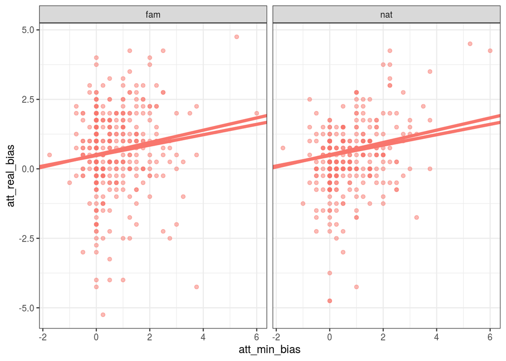

```r
df_rq3_rand <- left_join(df_rq3_att, model_coefs, by = "country")

ggplot(data = df_rq3_rand,
       mapping = aes(x = att_min_bias,
                     y = att_real_bias,
                     colour = lab)
       ) +
  geom_point(na.rm = T, alpha = 0.5) +
  geom_abline(aes(intercept = intercept,
                  slope = slope,
                  colour = lab
                  ),
              size = 1.5
              ) +
  facet_wrap(. ~ group_type) +
  guides(colour = "none") +
  theme_bw()
```

### First-party DG

We then repeat with the first-party DG.

```r
## real-world
model_real_world <-

    lmerTest::lmer(dg_real_bias_first ~ dg_min_bias_first * group_type +
                       (1 | id)  +
                       (dg_min_bias_first + group_type | country/lab),
                   data = df_rq3_dg_first)

## summary
summary(model_real_world)
```

```
## Linear mixed model fit by REML. t-tests use Satterthwaite's method [
## lmerModLmerTest]
## Formula: dg_real_bias_first ~ dg_min_bias_first * group_type + (1 | id) +
##     (dg_min_bias_first + group_type | country/lab)
##    Data: df_rq3_dg_first
##
## REML criterion at convergence: 4344
##
## Scaled residuals:
##    Min     1Q Median     3Q    Max
##  -5.81  -0.39   0.06   0.23   3.63
##
## Random effects:
##  Groups      Name              Variance Std.Dev. Corr
##  id          (Intercept)       5.24e-01 0.72375
##  lab:country (Intercept)       3.14e-03 0.05602
##              dg_min_bias_first 3.17e-05 0.00563  -1.00
##              group_typenat     1.77e-03 0.04209  -1.00  1.00
##  country     (Intercept)       7.99e-02 0.28272
##              dg_min_bias_first 7.93e-04 0.02816  -1.00
##              group_typenat     4.68e-02 0.21633  -1.00  1.00
##  Residual                      1.27e+01 3.56486
## Number of obs: 800, groups:  id, 400; lab:country, 2; country, 2
##
## Fixed effects:
##                                 Estimate Std. Error       df t value Pr(>|t|)
## (Intercept)                       1.3830     0.2780   1.0688    4.97   0.1145
## dg_min_bias_first                 0.2852     0.0601   7.8131    4.74   0.0016
## group_typenat                    -1.5825     0.3049   2.1464   -5.19   0.0302
## dg_min_bias_first:group_typenat  -0.0302     0.0784 397.5685   -0.38   0.7008
##
## (Intercept)
## dg_min_bias_first               **
## group_typenat                   *
## dg_min_bias_first:group_typenat
## ---
## Signif. codes:  0 '***' 0.001 '**' 0.01 '*' 0.05 '.' 0.1 ' ' 1
##
## Correlation of Fixed Effects:
##             (Intr) dg_m__ grp_ty
## dg_mn_bs_fr -0.422
## group_typnt -0.780  0.326
## dg_mn_bs_:_  0.129 -0.652 -0.235
## convergence code: 0
## boundary (singular) fit: see ?isSingular
```

```r
## ## run anova
## anova(model_real_world, ddf = "Kenward-Roger")
```

```r
model_coefs <-

  coef(model_real_world)$country %>%
  rename(intercept = `(Intercept)`, slope = dg_min_bias_first) %>%
  rownames_to_column("country")

model_coefs
```

| country | intercept | slope | group_typenat | dg_min_bias_first:group_typenat |
| --- | --- | --- | --- | --- |
| GBR | 1.2 | 0.30 | -1.5 | -0.03 |
| USA | 1.5 | 0.27 | -1.7 | -0.03 |

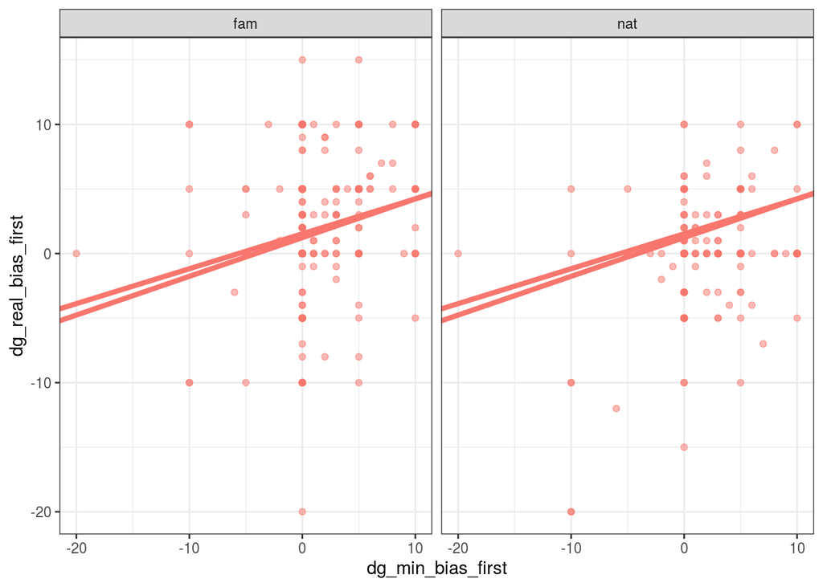

```r
df_rq3_rand <- left_join(df_rq3_dg_first, model_coefs, by = "country")

ggplot(data = df_rq3_rand,
       mapping = aes(x = dg_min_bias_first,
                     y = dg_real_bias_first,
                     colour = lab)
       ) +
  geom_point(na.rm = T, alpha = 0.5) +
  geom_abline(aes(intercept = intercept,
                  slope = slope,
                  colour = lab
                  ),
              size = 1.5
              ) +
  facet_wrap(. ~ group_type) +
  guides(colour = "none") +
  theme_bw()
```

### Third-party DG

We finally demonstrate the analysis with the third-party DG.

```r
## real-world
model_real_world <-

    lmerTest::lmer(dg_real_bias_third ~ dg_min_bias_third * group_type +
                       (1 | id)  +
                       (dg_min_bias_third + group_type | country/lab),
                   data = df_rq3_dg_third)

## summary
summary(model_real_world)
```

```
## Linear mixed model fit by REML. t-tests use Satterthwaite's method [
## lmerModLmerTest]
## Formula: dg_real_bias_third ~ dg_min_bias_third * group_type + (1 | id) +
##     (dg_min_bias_third + group_type | country/lab)
##    Data: df_rq3_dg_third
##
## REML criterion at convergence: 5687
##
## Scaled residuals:
##    Min     1Q Median     3Q    Max
## -3.357 -0.477 -0.115  0.555  2.345
##
## Random effects:
##  Groups      Name              Variance Std.Dev. Corr
##  id          (Intercept)       5.29e+00 2.29979
##  lab:country (Intercept)       7.26e-01 0.85186
##              dg_min_bias_third 1.09e-02 0.10446  -1.00
##              group_typenat     8.64e-04 0.02939   1.00 -1.00
##  country     (Intercept)       0.00e+00 0.00000
##              dg_min_bias_third 1.95e-08 0.00014    NaN
##              group_typenat     8.89e-06 0.00298    NaN -0.98
##  Residual                      6.61e+01 8.12765
## Number of obs: 800, groups:  id, 400; lab:country, 2; country, 2
##
## Fixed effects:
##                                  Estimate Std. Error        df t value Pr(>|t|)
## (Intercept)                       4.72307    0.77173   1.21476    6.12    0.074
## dg_min_bias_third                 0.20987    0.09797   1.63467    2.14    0.193
## group_typenat                    -3.87829    0.65678 246.39845   -5.90  1.2e-08
## dg_min_bias_third:group_typenat   0.00367    0.08751 397.93414    0.04    0.967
##
## (Intercept)                     .
## dg_min_bias_third
## group_typenat                   ***
## dg_min_bias_third:group_typenat
## ---
## Signif. codes:  0 '***' 0.001 '**' 0.01 '*' 0.05 '.' 0.1 ' ' 1
##
## Correlation of Fixed Effects:
##             (Intr) dg_m__ grp_ty
## dg_mn_bs_th -0.787
## group_typnt -0.400  0.192
## dg_mn_bs_:_  0.206 -0.447 -0.483
## convergence code: 0
## boundary (singular) fit: see ?isSingular
```

```r
## ## run anova
## anova(model_real_world, ddf = "Kenward-Roger")
```

```r
model_coefs <-

  coef(model_real_world)$country %>%
  rename(intercept = `(Intercept)`, slope = dg_min_bias_third) %>%
  rownames_to_column("country")

model_coefs
```

| country | intercept | slope | group_typenat | dg_min_bias_third:group_typenat |
| --- | --- | --- | --- | --- |
| GBR | 4.7 | 0.21 | -3.9 | 0.0037 |
| USA | 4.7 | 0.21 | -3.9 | 0.0037 |

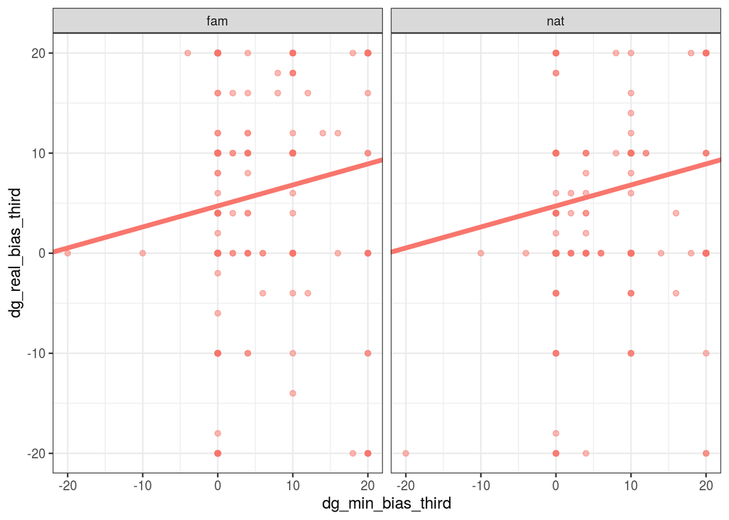

```r
df_rq3_rand <- left_join(df_rq3_dg_third, model_coefs, by = "country")

ggplot(data = df_rq3_rand,
       mapping = aes(x = dg_min_bias_third,
                     y = dg_real_bias_third,
                     colour = lab)
       ) +
  geom_point(na.rm = T, alpha = 0.5) +
  geom_abline(aes(intercept = intercept,
                  slope = slope,
                  colour = lab
                  ),
              size = 1.5
              ) +
  facet_wrap(. ~ group_type) +
  guides(colour = "none") +
  theme_bw()
```